# PML Course Project

Alex Ivanova

## Objectives

Using devices such as Jawbone Up, Nike FuelBand, and Fitbit it is now possible to collect a large amount of data about personal activity relatively inexpensively. These type of devices are part of the quantified self movement – a group of enthusiasts who take measurements about themselves regularly to improve their health, to find patterns in their behavior, or because they are tech geeks. One thing that people regularly do is quantify how much of a particular activity they do, but they rarely quantify how well they do it. The goal of this project is to use data from accelerometers on the belt, forearm, arm, dumbell of 6 participants, and predict the manner in which they did the exercise. The data for this project come from this [source](http://web.archive.org/web/20161224072740/http:/groupware.les.inf.puc-rio.br/har).

### Reading in and Looking at Data

We have two datasets — a training set and a testing one. The testing set has 20 observations and the training set set has 19,622 observations with 160 features. Class A corresponds to the specified execution of the exercise, while the other 4 classes correspond to common mistakes.

```r
pml_training <- read.csv("https://d396qusza40orc.cloudfront.net/predmachlearn/pml-training.csv", header = TRUE, na.strings = c("NA","#DIV/0!", ""))
pml_testing <- read.csv("https://d396qusza40orc.cloudfront.net/predmachlearn/pml-testing.csv", header = TRUE, na.strings = c("NA","#DIV/0!", ""))
unique(pml_training$classe)
```

```
## [1] "A" "B" "C" "D" "E"
```

### Cleaning the Data

Firstly, we can look at the percentage of NA values in the data.

```r
colMeans(is.na(pml_training))
```

```
##                        X                user_name     raw_timestamp_part_1
##                0.0000000                0.0000000                0.0000000
##     raw_timestamp_part_2           cvtd_timestamp               new_window
##                0.0000000                0.0000000                0.0000000
##               num_window                roll_belt               pitch_belt
##                0.0000000                0.0000000                0.0000000
##                 yaw_belt         total_accel_belt       kurtosis_roll_belt
##                0.0000000                0.0000000                0.9798186
##      kurtosis_picth_belt        kurtosis_yaw_belt       skewness_roll_belt
##                0.9809398                1.0000000                0.9797676
##     skewness_roll_belt.1        skewness_yaw_belt            max_roll_belt
##                0.9809398                1.0000000                0.9793089
##           max_picth_belt             max_yaw_belt            min_roll_belt
##                0.9793089                0.9798186                0.9793089
##           min_pitch_belt             min_yaw_belt      amplitude_roll_belt
##                0.9793089                0.9798186                0.9793089
##     amplitude_pitch_belt       amplitude_yaw_belt     var_total_accel_belt
##                0.9793089                0.9798186                0.9793089
##            avg_roll_belt         stddev_roll_belt            var_roll_belt
##                0.9793089                0.9793089                0.9793089
##           avg_pitch_belt        stddev_pitch_belt           var_pitch_belt
##                0.9793089                0.9793089                0.9793089
##             avg_yaw_belt          stddev_yaw_belt             var_yaw_belt
##                0.9793089                0.9793089                0.9793089
##             gyros_belt_x             gyros_belt_y             gyros_belt_z
##                0.0000000                0.0000000                0.0000000
##             accel_belt_x             accel_belt_y             accel_belt_z
##                0.0000000                0.0000000                0.0000000
##            magnet_belt_x            magnet_belt_y            magnet_belt_z
##                0.0000000                0.0000000                0.0000000
##                 roll_arm                pitch_arm                  yaw_arm
##                0.0000000                0.0000000                0.0000000
##          total_accel_arm            var_accel_arm             avg_roll_arm
##                0.0000000                0.9793089                0.9793089
##          stddev_roll_arm             var_roll_arm            avg_pitch_arm
##                0.9793089                0.9793089                0.9793089
##         stddev_pitch_arm            var_pitch_arm              avg_yaw_arm
##                0.9793089                0.9793089                0.9793089
##           stddev_yaw_arm              var_yaw_arm              gyros_arm_x
##                0.9793089                0.9793089                0.0000000
```

[output cut: 53 more lines]

```
##                0.9835898                0.0000000                0.9793089
##         avg_roll_forearm      stddev_roll_forearm         var_roll_forearm
##                0.9793089                0.9793089                0.9793089
##        avg_pitch_forearm     stddev_pitch_forearm        var_pitch_forearm
##                0.9793089                0.9793089                0.9793089
##          avg_yaw_forearm       stddev_yaw_forearm          var_yaw_forearm
##                0.9793089                0.9793089                0.9793089
##          gyros_forearm_x          gyros_forearm_y          gyros_forearm_z
##                0.0000000                0.0000000                0.0000000
##          accel_forearm_x          accel_forearm_y          accel_forearm_z
##                0.0000000                0.0000000                0.0000000
##         magnet_forearm_x         magnet_forearm_y         magnet_forearm_z
##                0.0000000                0.0000000                0.0000000
##                   classe
##                0.0000000
```

We can see that there are a lot of columns with almost 100% of missing values. When using ML algorithms, those won’t be of much relevance. Also some columns have no useful for prediction information, such as the name of the participant or time stamps. Therefore, we can safely delete them.

```r
pml_training_clean <- pml_training[colMeans(is.na(pml_training)) < 0.9]
pml_testing_clean <- pml_testing[colMeans(is.na(pml_testing)) < 0.9]
pml_training_clean <- pml_training_clean[, -c(1:7)]
pml_testing_clean <- pml_testing_clean[, -c(1:7)]
pml_training_clean$classe <- as.factor(pml_training_clean$classe)
```

### Partitioning the Data

Cross-validation will be performed as following: since we have both a testing set and a training set, let’s partition the data further and use our testing set with 20 tests for validation. And the training data will be split into classic 60/40 training/test sets. Also the seed will be set for the purpose of reproducibility.

```r
library(caret)
set.seed(1234)
partition <- createDataPartition(y = pml_training_clean$classe,
                                 p = 0.6, list = FALSE)
training <- pml_training_clean[partition, ]
testing <- pml_training_clean[-partition, ]
```

## Prediction Using Decision Trees

The data is continuous, so we will be predicting using decision trees and random forests. Firstly, we’ll try decision trees.

```r
library(rpart)
library(rattle)
```

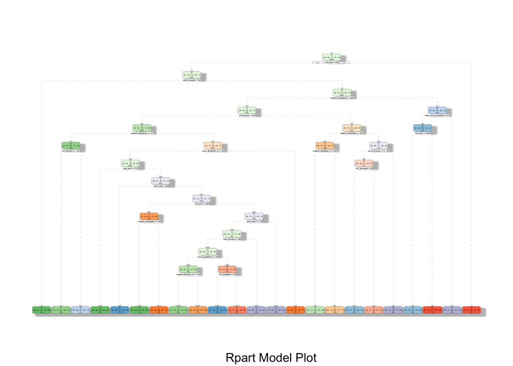

```r
rpartModel <- rpart(factor(classe) ~ ., data = training, method = "class")
rpartPrediction <- predict(rpartModel, newdata = testing, type = "class")
fancyRpartPlot(rpartModel, sub = "Rpart Model Plot")
```

The plot was made using the `rattle` package.

```r
CM <- confusionMatrix(rpartPrediction, testing$classe)
CM$table
```

```
##           Reference
## Prediction    A    B    C    D    E
##          A 1930  231   47   81   53
##          B   82  866   67  103  121
##          C   59  189 1062  173  134
##          D   94  118   85  821   70
##          E   67  114  107  108 1064
```

```r
CM$overall[1]
```

```
##  Accuracy
## 0.7319653
```

As we can see, the accuracy equals 73%. The expected out-of-sample error is `1 - accuracy`, which is 27%.

## Prediction Using Random Forests

Now we will try the random forest algorithm.

```r
library(randomForest)
RFModel <- randomForest(factor(classe) ~ ., data = training, method = "class")
RFPrediction <- predict(RFModel, newdata = testing, type = "class")
CMrf <- confusionMatrix(RFPrediction, testing$classe)
CMrf$table
```

```
##           Reference
## Prediction    A    B    C    D    E
##          A 2230   12    0    0    0
##          B    1 1506    5    0    0
##          C    0    0 1357   10    3
##          D    1    0    6 1274    5
##          E    0    0    0    2 1434
```

```r
CMrf$overall[1]
```

```
##  Accuracy
## 0.9942646
```

The accuracy is 99%. The expected out-of-sample error is `1 - accuracy`, which is 0.5%.

## Conclusion

The random forest algorithm performed much better than decision trees — 99% versus 73%.

### Validation

Now let’s perform the chosen model on the validation set.

```r
valPrediction <- predict(RFModel, pml_testing_clean, type = "class")
valPrediction
```

```
##  1  2  3  4  5  6  7  8  9 10 11 12 13 14 15 16 17 18 19 20
##  B  A  B  A  A  E  D  B  A  A  B  C  B  A  E  E  A  B  B  B
## Levels: A B C D E
```